# Nanofish: GPx activity

# Set up environment

## Load libraries

## Load functions

## Load data

### Adjust classes and transformations

```
'data.frame':   467 obs. of  30 variables:
 $ StudyID             : Factor w/ 59 levels "2","3","4","5",..: 40 40 50 50 50 50 16 16 16 7 ...
 $ StudyCluster        : Factor w/ 34 levels "1","2","3","5",..: 4 4 5 5 5 5 4 4 4 18 ...
 $ Study               : Factor w/ 59 levels "Ašmonaitė et al., 2020",..: 1 1 2 2 2 2 3 3 3 4 ...
 $ Year                : int  2020 2020 2018 2018 2018 2018 2020 2020 2020 2019 ...
 $ EScluster           : Factor w/ 101 levels "1","2","3","4",..: 1 1 2 2 2 2 3 3 3 4 ...
 $ AdministrationRoute : Factor w/ 6 levels "Food","Injection",..: 1 1 4 4 4 4 1 1 1 4 ...
 $ Concentration_mg_L  : num  NA NA 0.26 0.69 0.26 0.69 NA NA NA 20 ...
 $ ParticleMaterial    : Factor w/ 7 levels "Aminoplast","LDPE",..: 6 3 1 1 1 1 3 3 3 6 ...
 $ Species             : Factor w/ 20 levels "Argyrosomus regius",..: 9 9 8 8 8 8 9 9 9 7 ...
 $ ParticleShape       : Factor w/ 4 levels "Irregular","Sphere",..: 2 2 2 2 2 2 2 2 2 2 ...
 $ Sex                 : Factor w/ 5 levels "F","F:M","FM",..: 5 5 5 5 5 5 5 5 5 NA ...
 $ DevelopmentalStage  : Factor w/ 5 levels "Embrio","Larva",..: 4 4 4 4 4 4 4 4 4 2 ...
 $ ExposureDurationCat : Factor w/ 3 levels "15 days +","5-15 days",..: 2 2 3 3 3 3 1 1 1 3 ...
 $ ExposureDurationDays: int  14 14 4 4 4 4 28 28 28 2 ...
```

[output cut: 16 more lines]

### Calculate Effect Size

```r
df_original <- metafor::escalc(measure = "SMD", n1i = n_treat, n2i = n_ctrl, m1i = mean_treat,
    m2i = mean_ctrl, sd1i = STD_treat, sd2i = STD_ctrl, data = df_original, vtype = "UB")
# write.csv(df_original,file = 'mvMetaAnalysis_SMDs.csv')
```

### Create variables

```r
outcome <- as.character(outcomeslist[[n_outcome]])

mRF <- list()  # random effects formula investigation models
mRE <- list()  # random effects multilevel models
mMR <- list()  # multilevel metaregression models

colormap <- c(Embrio = "khaki", Larva = "lightgreen", Juvenile = "lightskyblue",
    Adult = "salmon", Unclear = "plum", ExposureDurationDays = "cornflowerblue",
    ParticleSizeMean = "chartreuse4", Concentration_mg_L = "#fa0079ff", Aminoplast = "chocolate4",
    LDPE = "#2200faff", PE = "#0089faff", PET = "#00faedff", PLA = "#00fa29ff", PS = "#faf200ff",
    PVC = "#fa9a00ff", `Publication year` = "black", Variance = "navyblue")
```

### Select outcome

```
[1] "GPx activity"
```

|  | StudyID | StudyCluster | Study | Year | EScluster | AdministrationRoute | Concentration_mg_L | ParticleMaterial | Species | ParticleShape | Sex | DevelopmentalStage | ExposureDurationCat | ExposureDurationDays | ParticleSizeRange | ParticleSizeMean | ParticleSizeCat | Outcome | OutcomeCategory | Test_or_Assay | OutcomeVariable | Group | n_of_groups | n_ctrl | mean_ctrl | STD_ctrl | n_treat | mean_treat | STD_treat | … |
| --- | --- | --- | --- | --- | --- | --- | --- | --- | --- | --- | --- | --- | --- | --- | --- | --- | --- | --- | --- | --- | --- | --- | --- | --- | --- | --- | --- | --- | --- | --- |
| 43 | 76 | 11 | Chen et al., 2017 | 2017 | 10 | Water: Semi-static system | 1 | PS | Danio rerio | Sphere |  | Larva | 5-15 days | 5 | 45 | 45 | micro | GPx activity | Neurochemical outcomes | Oxidative Stress | GPx activity | MPP | 2 | 3 | 1.645 | 0.058 | 3 | 1.608 | 0.052 | … |
| 44 | 76 | 11 | Chen et al., 2017 | 2017 | 10 | Water: Semi-static system | 1 | PS | Danio rerio | Sphere |  | Larva | 5-15 days | 5 | 0.05 | 0.05 | nano | GPx activity | Neurochemical outcomes | Oxidative Stress | GPx activity | NPP | 2 | 3 | 1.645 | 0.058 | 3 | 1.457 | 0.082 | … |
| 124 | 66 | 30 | Iheanacho &amp; Odo, 2020 | 2020 | 46 | Food |  | PVC | Clarias gariepinus | Unclear |  | Juvenile | 15 days + | 45 | 95 | 95 | micro | GPx activity | Neurochemical outcomes | Oxidative Stress | GPx activity | 0.5 | 3 | 9 | 23.52 | 2.13 | 9 | 20.14 | 1.39 | … |
| 125 | 66 | 30 | Iheanacho &amp; Odo, 2020 | 2020 | 46 | Food |  | PVC | Clarias gariepinus | Unclear |  | Juvenile | 15 days + | 45 | 95 | 95 | micro | GPx activity | Neurochemical outcomes | Oxidative Stress | GPx activity | 1.5 | 3 | 9 | 23.52 | 2.13 | 9 | 22.87 | 2.82 | … |
| 126 | 66 | 30 | Iheanacho &amp; Odo, 2020 | 2020 | 46 | Food |  | PVC | Clarias gariepinus | Unclear |  | Juvenile | 15 days + | 45 | 95 | 95 | micro | GPx activity | Neurochemical outcomes | Oxidative Stress | GPx activity | 3 | 3 | 9 | 23.52 | 2.13 | 9 | 21.64 | 1.47 | … |
| 143 | 79 | 30 | Iheanacho et al., 2020 | 2020 | 47 | Food |  | Aminoplast | Clarias gariepinus | Unclear |  | Juvenile | 15 days + | 45 | 95 | 95 | micro | GPx activity | Neurochemical outcomes | Oxidative Stress | GPx activity | MEF | 2 | 9 | 26.012 | 3.831 | 9 | 20.769 | 3.092 | … |
| 144 | 79 | 30 | Iheanacho et al., 2020 | 2020 | 47 | Food |  | PVC | Clarias gariepinus | Unclear |  | Juvenile | 15 days + | 45 | 95 | 95 | micro | GPx activity | Neurochemical outcomes | Oxidative Stress | GPx activity | PVC | 2 | 9 | 26.012 | 3.831 | 9 | 20.769 | 3.092 | … |
| 190 | 107 | 27 | Parenti et al., 2021 | 2021 | 60 | Water: Semi-static system | 0.2 | PS | Danio rerio | Unclear |  | Larva | 5-15 days | 7 | 0.5 | 0.5 | nano | GPx activity | Neurochemical outcomes | Oxidative Stress | GPx activity | PNP | 1 | 3 | 128.121 | 14.731 | 3 | 150.069 | 3.801 | … |
| 204 | 103 | 15 | Pitt et al., 2018b | 2018 | 64 | Food |  | PS | Danio rerio | Unclear | F | Adult | 5-15 days | 7 | 0.042 | 0.042 | nano | GPx activity | Neurochemical outcomes | Oxidative Stress | GPx activity | Exposed | 1 | 10 | 0.992 | 0.165 | 10 | 1.194 | 0.227 | … |
| 205 | 103 | 15 | Pitt et al., 2018b | 2018 | 65 | Food |  | PS | Danio rerio | Unclear | M | Adult | 5-15 days | 7 | 0.042 | 0.042 | nano | GPx activity | Neurochemical outcomes | Oxidative Stress | GPx activity | Exposed | 1 | 10 | 0.992 | 0.217 | 10 | 1.06 | 0.217 | … |

[output cut: 35 more lines]

# Exploratory data analysis

## Funnel plot

> Before running any meta-analytic model, it is important to explore the meta-analytic dataset to search for potential outliers that could represent data extraction errors. (Nakagawa et al. 2022)

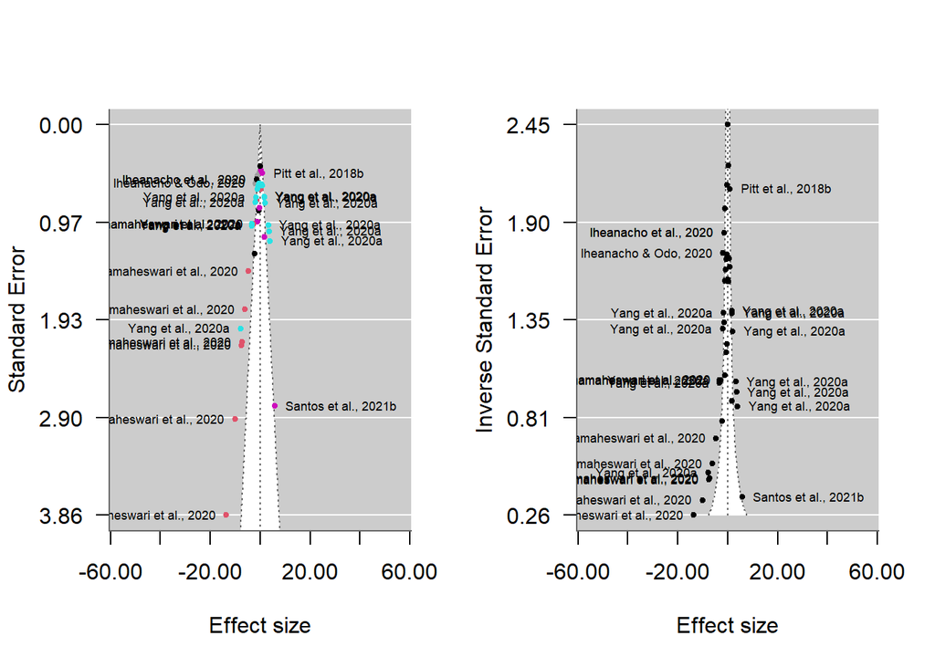

## Forest plot

https://www.rdocumentation.org/packages/meta/versions/8.0-2/topics/forest.meta

## Alluvial plot

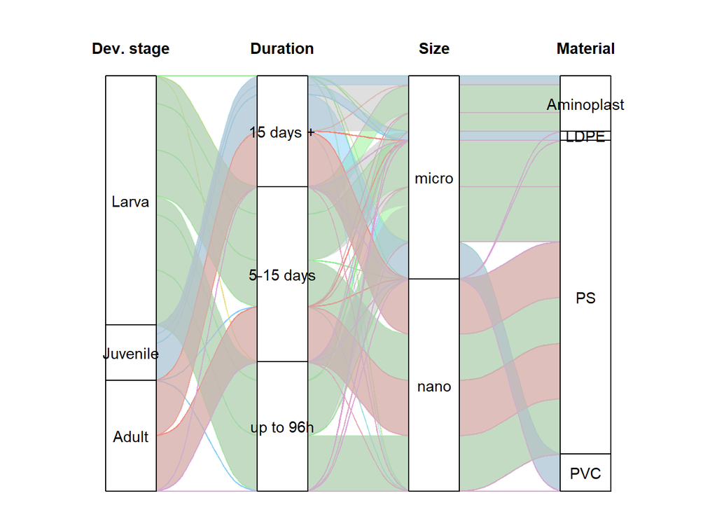

# Multilevel meta-analytic model

## Random effects formula desing

```
[1] "Considering number of studies: 11, number of ES clusters: 21 and number of independent observations of ES: 45, the random effects formula for GPx activity is: ~1 | Study/EScluster/ESid"
```

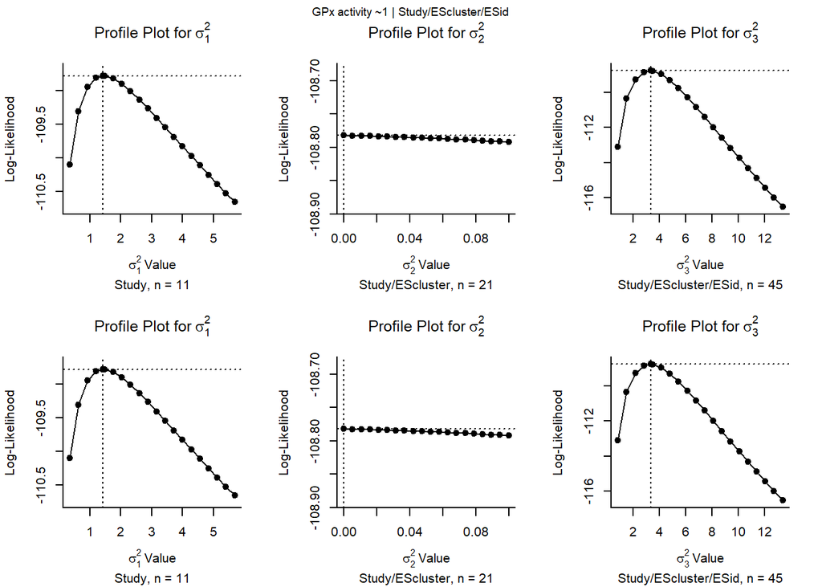

> A profile likelihood plot should show a single peak at the corresponding ML/REML estimate. If `refline=TRUE` (the default), the value of the parameter estimate is indicated by a dotted vertical line and its log-likelihood value by a dotted horizontal line. Hence, the intersection of these two lines should correspond to the peak (assuming that the model was fitted with ML/REML estimation).

> When profiling a variance component (or some other parameter that cannot be negative), the peak may be at zero (if this corresponds to the ML/REML estimate of the parameter). In this case, the profiled log-likelihood should be a monotonically decreasing function of the parameter. Similarly, when profiling a correlation component, the peak may be at -1 or +1.

> If the profiled log-likelihood has multiple peaks, this indicates that the likelihood surface is not unimodal. In such cases, the ML/REML estimate may correspond to a local optimum (when the intersection of the two dotted lines is not at the highest peak).

> If the profile is flat (over the entire parameter space or large portions of it), then this suggests that at least some of the parameters of the model are not identifiable (and the parameter estimates obtained are to some extent arbitrary). See Raue et al. (2009) for some further discussion of parameter identifiability and the use of profile likelihoods to check for this.

> The function checks whether any profiled log-likelihood value is actually larger than the log-likelihood of the fitted model (using a numerical tolerance of `lltol`). If so, a warning is issued as this might indicate that the optimizer did not identify the actual ML/REML estimate of the parameter profiled.[Viechtbauer (2022)](Viechtbauer 2010)

## Additional random effects factors

Study cluster, particle material and species as random effects term can further improve results?

|  | Nested | +StudyCluster | +Particle Material | +Species |
| --- | --- | --- | --- | --- |
| logLik: | -108.7822118179055 | -108.4764291273167 | -108.7822118147276 | -108.7822118194081 |
| deviance: | 145.4100672300252 | 144.7985018488476 | 145.4100672236694 | 145.4100672330304 |
| AIC: | 225.5644236358109 | 226.9528582546334 | 227.5644236294551 | 227.5644236388162 |
| BIC: | 232.7910735948922 | 235.986170703485 | 236.5977360783068 | 236.5977360876678 |
| AICc: | 226.5644236358109 | 228.491319793095 | 229.1028851679167 | 229.1028851772778 |

|  | Comparison | LRT | p_value |
| --- | --- | --- | --- |
| 1 | +Study Cluster | 0.61 | 0.434 |
| 2 | +Particle Material | 0 | 1 |
| 3 | +Species | 0 | 1 |

Additional term to insert: none

## Main result: Multilevel model with $\rho = 0.5$ and robust variance estimate

```r
# Assumed correlation of rho = 0.5, except if there is only one ES by Study (no
# correlation)
if (nES == nSt) {
    VCVrho <- 0
    VCV <- df$vi
} else {
    VCVrho <- 0.5
    VCV <- vcalc(vi, cluster = interaction(df$EScluster, df$Study), obs = ESid, data = df,
        rho = VCVrho)
}

mname1 <- "ML"
mname2 <- paste0(mname1, "_RobVar")

mRE[[mname1]] <- rma.mv(yi, VCV, random = RE_formula, data = df, slab = Study, method = "REML",
    test = "t", dfs = "contain", level = 95)
mRE[[mname1]] <- additional_results(mRE[[mname1]])

mRE[[mname2]] <- robust(mRE[[mname1]], cluster = df$Study, clubSandwich = TRUE)

mRE[[mname2]] <- additional_results(mRE[[mname2]])

I2_ML_RobVar <- i2_ml(mRE[[mname2]])
# I2_ML_RobVar <- i2_ml(mRE[[mname2]], boot = 1000)

extract_report(mRE[[mname2]], outcome, RE_formula)
```

#### Diagnostics plots and results

```
Multivariate Meta-Analysis Model (k = 45; method: REML)

   logLik   Deviance        AIC        BIC       AICc
-106.9385   213.8769   221.8769   229.0137   222.9026

Variance Components:

            estim    sqrt  nlvls  fixed                factor
sigma^2.1  1.4130  1.1887     11     no                 Study
sigma^2.2  0.0000  0.0002     21     no       Study/EScluster
sigma^2.3  4.0811  2.0202     45     no  Study/EScluster/ESid

Test for Heterogeneity:
Q(df = 44) = 302.3532, p-val < .0001

Number of estimates:   45
Number of clusters:    11
Estimates per cluster: 0-18 (mean: 0.76, median: 0)

Model Results:

estimate      se¹     tval¹    df¹    pval¹    ci.lb¹   ci.ub¹
 -0.6423  0.5826   -1.1025   8.22   0.3015   -1.9795   0.6949

---
Signif. codes:  0 '***' 0.001 '**' 0.01 '*' 0.05 '.' 0.1 ' ' 1

1) results based on cluster-robust inference (var-cov estimator: CR2,
   approx t-test and confidence interval, df: Satterthwaite approx)
```

```
               I2_Total                I2_Study      I2_Study/EScluster
           9.112474e+01            2.343570e+01            4.822242e-07
I2_Study/EScluster/ESid
           6.768904e+01
```

```
$results
        % of total variance    I2
Level 1        8.875260e+00   ---
Level 2        6.768904e+01 67.69
Level 3        4.822242e-07     0
Level 4        2.343570e+01 23.44

$totalI2
[1] 91.12474

$plot
```

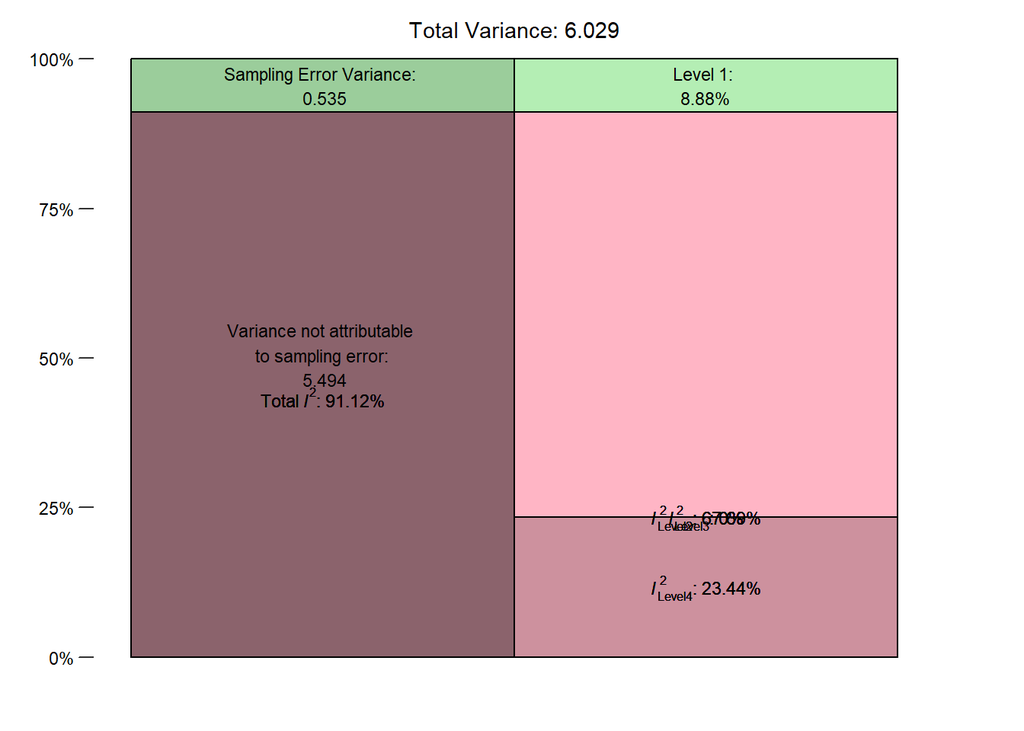

```
attr(,"class")
[1] "mlm.variance.distribution" "list"
```

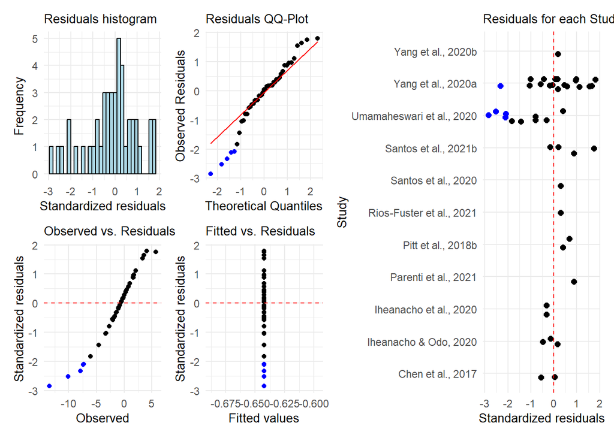

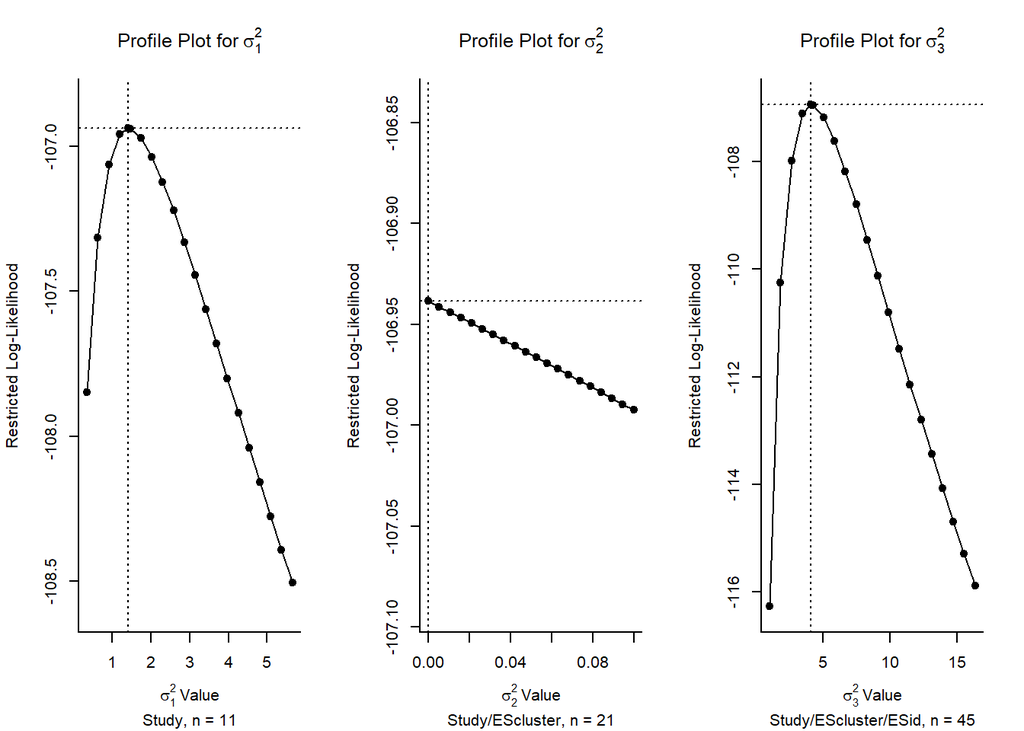

The meta-analysis comprised 45 comparisons from 21 control group clusters of 11 independent studies, so the random formula for GPx activity was ~1 | Study/EScluster/ESid.

No difference between treatment and control groups (ES = -0.6422858 ± 0.5825727, CI95% = -1.9794958 to 0.6949242, predicted interval -6.1861652 to 4.9015936), with high heterogeneity (i² = 91.12, Q = 302.3532134, p < 0.001 ) and variance explained by each component of $\sigma^2_{Study} = 1.41$, $\sigma^2_{EScluster} = 0.00$, $\sigma^2_{ESid} = 4.08$.

# Publication bias

> **Small-study effect:** when small studies (with small sample sizes) tend to report large effect sizes. (Yang et al. 2023)

> While the PET method works best when the true effect captured by β0β0 is **zero**, PEESE shows a better performance when the true effect is **not** zero. Stanley and Doucouliagos ([2014](https://bookdown.org/MathiasHarrer/Doing_Meta_Analysis_in_R/references.html#ref-stanley2014meta)) therefore proposed to combine both methods, in order to balance out their individual strengths. The resulting approach is the PET-PEESE method. PET-PEESE uses the intercept β0 of either PET or PEESE as the estimate of the corrected true effect.

> Whether PET or PEESE is used depends on the size of the intercept calculated by the PET method. When β0PET is significantly larger than zero in a one-sided test with α = 0.05, we use the intercept of PEESE as the true effect size estimate. If PET’s intercept is not significantly larger than zero, we remain with the PET estimate.

> In most implementations of regression models in *R*, it is conventional to test the significance of coefficients using a two-sided test (i.e. we test if a ββ weight significantly differs from zero, no matter the direction). To assume a one-sided test with α = 0.05, we already regard the intercept as significant when p < 0.1, and when the estimate of β0 is larger than zero<sup>38</sup>. (Harrer et al., n.d.)

> **Time-lag bias:** when statistically significant (“positive” results) tend to be published earlier than those with statistically non-significant findings (“negative” results), leading to a decline in reported effect sizes over time (i.e., a decline effect). (Yang et al. 2023)

> Given that high heterogeneity may invalidate publication bias test, it is best to account for the potential heterogeneity when testing publication bias. (Yang et al. 2023)

> PET-PEESE performs poorly in research areas where there are only a few studies, all studies use small samples, and where there is very high heterogeneity of results from study to study. Nonetheless, the statistical properties of conventional meta-analysis approaches are much worse than PET-PEESE under these same conditions.(Stanley 2017)

So, **better use meta-regression dataset**, but requires larger dataset to avoid possible convergence issues.

#### Plots

```
[1] "PET"
```

```
Multivariate Meta-Analysis Model (k = 45; method: REML)

  logLik  Deviance       AIC       BIC      AICc
-96.4257  192.8514  204.8514  215.2774  207.2514

Variance Components:

            estim    sqrt  nlvls  fixed                factor
sigma^2.1  0.8690  0.9322     11     no                 Study
sigma^2.2  0.0000  0.0001     21     no       Study/EScluster
sigma^2.3  3.4367  1.8538     45     no  Study/EScluster/ESid

Test for Residual Heterogeneity:
QE(df = 42) = 275.3221, p-val < .0001

Number of estimates:   45
Number of clusters:    11
Estimates per cluster: 0-18 (mean: 0.76, median: 0)

Test of Moderators (coefficients 2:3):¹
F(df1 = 2, df2 = 2.01) = 1.1672, p-val = 0.4610

Model Results:

          estimate      se¹     tval¹    df¹    pval¹     ci.lb¹   ci.ub¹
intrcpt     1.5647  1.1934    1.3112   5.07   0.2461    -1.4909   4.6203
ESSE       -2.6055  1.9018   -1.3700   2.16   0.2958   -10.2394   5.0283
pub_year    0.2675  0.3596    0.7439   2.07   0.5323    -1.2333   1.7684

---
Signif. codes:  0 '***' 0.001 '**' 0.01 '*' 0.05 '.' 0.1 ' ' 1

1) results based on cluster-robust inference (var-cov estimator: CR2,
   approx t/F-tests and confidence intervals, df: Satterthwaite approx)
```

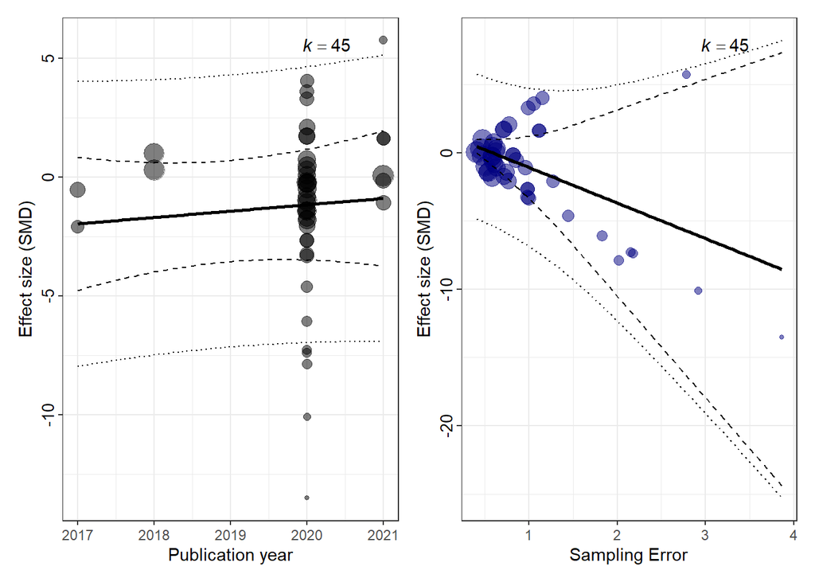

**Small-study effect** The regression slope of the extended Egger’s regression is $\sqrt{SMDSE} = -2.6055485$ is it statistically different from zero?`

If p<0.050: Smaller studies (with larger sampling error) have larger effect sizes –> small-study effect exists in this dataset. Data is assymmetrically distributed in the funnel plot.

If p>=0.050 no small-study effect exists in this dataset. Smaller studies (with larger sampling error) do not have larger effect sizes –> no small-study effect exists in this dataset. Data is symmetrically distributed in the funnel plot.

If p<0.050: studies with statistically significant findings tend to be published earlier than these with “negative” results, i.e. time-lag bias exists in this dataset

If p>=0.050: studies with statistically significant findings **do not** tend to be published earlier than these with “negative” results, i.e. no time-lag bias exists in this dataset

### Sensitivity analysis: publication bias with adapted SE

> Egger’s regression and its variants suffer from low power and poor performance when there are fewer than 20 effect sizes, or when the overall effect is large. (Nakagawa et al. 2022)

> Instead of the sample size (n1 + n2), however, for a meta-analysis of SMD or lnRR, we propose using the ‘effective sample size’ because it accounts for unbalanced sampling (cf. Stanley, 2005).(Nakagawa et al. 2022)

```r
if (mRE[[bias]]$pval[2] < 0.05) {

    # calculate modified SE based on effective sample size
    df$ess_vi <- with(df, sqrt((n_treat + n_ctrl)/(n_treat * n_ctrl)))
    df$ess_SE <- sqrt(df$ess_vi)  ## sampling error for ES

    # PET + year
    bias2 <- "PET sensitivity"
    mRE[[bias2]] <- rma.mv(yi, VCV, random = RE_formula, mods = ~ess_SE + pub_year,
        data = df, slab = Study, method = "REML", test = "t", dfs = "contain", level = 95)
    mRE[[bias2]] <- robust(mRE[[bias2]], cluster = df$Study, clubSandwich = TRUE)
    mRE[[bias2]] <- additional_results(mRE[[bias2]])

    # PEESE + year
    if (mRE[[bias2]]$pval[2] < 0.1) {
        mname <- "PEESE sensitivity"
        mRE[[mname]] <- rma.mv(yi, VCV, random = RE_formula, mods = ~ess_vi + pub_year,
            data = df, slab = Study, method = "REML", test = "t", dfs = "contain",
            level = 95)
        mRE[[mname]] <- robust(mRE[[mname]], cluster = df$Study, clubSandwich = TRUE)
        mRE[[mname]] <- additional_results(mRE[[mname]])
        bias2 <- mname
    }
    print(bias2)
    summary(mRE[[bias2]])
}
```

If the results are the same, indicates the robustness of the small-study test.

#### Plots

# Sensitivity

## Rho range

```r
if (VCVrho != 0) {

    rho_range <- c(0, 0.25, 0.75, 0.9)  # assume a range values of rho

    for (j in 1:length(rho_range)) {

        mname <- paste("rho", rho_range[j], sep = "_")

        VCV2 <- vcalc(vi, cluster = interaction(df$EScluster, df$Study), obs = ESid,
            data = df, rho = rho_range[j])

        mRE[[mname]] <- rma.mv(yi, VCV2, random = RE_formula, data = df, slab = Study,
            method = "REML", test = "t", dfs = "contain", level = 95)
        mRE[[mname]] <- robust(mRE[[mname]], cluster = df$Study, clubSandwich = TRUE)
        mRE[[mname]] <- additional_results(mRE[[mname]])
    }
}
```

## Leave one out + Rho range

```r
if (VCVrho != 0) {
    rho_range <- c(0.25, 0.5, 0.75, 0.9)
} else {
    rho_range <- 0
}

for (i in sort(unique(df$Study))) {

    df_temp <- df[df$Study != i, ]

    for (j in 1:length(rho_range)) {

        mname <- paste("rho", rho_range[j], "l1o", i, sep = "_")
        print(mname)
        VCV2 <- vcalc(vi, cluster = interaction(df_temp$EScluster, df_temp$Study),
            obs = ESid, data = df_temp, rho = rho_range[j])

        mRE[[mname]] <- rma.mv(yi, VCV2, random = RE_formula, data = df_temp, slab = Study,
            method = "REML", test = "t", dfs = "contain", level = 95)
        mRE[[mname]] <- robust(mRE[[mname]], cluster = df_temp$Study, clubSandwich = TRUE)
        mRE[[mname]] <- additional_results(mRE[[mname]])
    }
}
```

```
[1] "rho_0.25_l1o_Chen et al., 2017"
[1] "rho_0.5_l1o_Chen et al., 2017"
[1] "rho_0.75_l1o_Chen et al., 2017"
[1] "rho_0.9_l1o_Chen et al., 2017"
[1] "rho_0.25_l1o_Iheanacho & Odo, 2020"
[1] "rho_0.5_l1o_Iheanacho & Odo, 2020"
[1] "rho_0.75_l1o_Iheanacho & Odo, 2020"
[1] "rho_0.9_l1o_Iheanacho & Odo, 2020"
[1] "rho_0.25_l1o_Iheanacho et al., 2020"
[1] "rho_0.5_l1o_Iheanacho et al., 2020"
[1] "rho_0.75_l1o_Iheanacho et al., 2020"
[1] "rho_0.9_l1o_Iheanacho et al., 2020"
[1] "rho_0.25_l1o_Parenti et al., 2021"
[1] "rho_0.5_l1o_Parenti et al., 2021"
[1] "rho_0.75_l1o_Parenti et al., 2021"
```

[output cut: 29 more lines]

# Tables

|  | n studies | n ES clusters | n ES | overall effect | standard error | p-value | Lower CI | Upper CI | Lower PI | Upper PI | Q | Q p-value | $I^2$$_{total}$ | $I^2$$_{Study}$ | $I^2$$_{EScluster}$ | $I^2$$_{ES}$ | $\sigma^2$$_{Study}$ | $\sigma^2$$_{EScluster}$ | $\sigma^2$$_{ES}$ |
| --- | --- | --- | --- | --- | --- | --- | --- | --- | --- | --- | --- | --- | --- | --- | --- | --- | --- | --- | --- |
| ML | 11 | 21 | 45 | -0.64 | 0.6 | 0.2805 | -1.90 | 0.61 | -6.01 | 4.73 | 302.35 | 0 | 91.12 | 23.44 | 0.00 | 67.69 | 1.41 | 0.00 | 4.08 |
| ML_RobVar | 11 | 21 | 45 | -0.64 | 0.6 | 0.3015 | -1.98 | 0.69 | -6.19 | 4.90 | 302.35 | 0 | 91.12 | 23.44 | 0.00 | 67.69 | 1.41 | 0.00 | 4.08 |
| PET | 11 | 21 | 45 | 1.56 | 1.2 | 0.2461 | -1.49 | 4.62 | -4.56 | 7.69 | 275.32 | 0 | 88.95 | 17.95 | 0.00 | 70.99 | 0.87 | 0.00 | 3.44 |
| rho_0 | 11 | 21 | 45 | -0.68 | 0.6 | 0.2737 | -2.00 | 0.64 | -6.00 | 4.64 | 232.84 | 0 | 90.52 | 29.34 | 0.28 | 60.90 | 1.66 | 0.02 | 3.44 |
| rho_0.25 | 11 | 21 | 45 | -0.66 | 0.6 | 0.2856 | -1.98 | 0.66 | -6.03 | 4.72 | 243.93 | 0 | 90.67 | 26.43 | 0.00 | 64.23 | 1.52 | 0.00 | 3.68 |
| rho_0.75 | 11 | 21 | 45 | -0.63 | 0.6 | 0.3195 | -2.00 | 0.74 | -6.41 | 5.15 | 508.01 | 0 | 91.72 | 20.53 | 0.00 | 71.19 | 1.33 | 0.00 | 4.60 |
| rho_0.9 | 11 | 21 | 45 | -0.62 | 0.6 | 0.3309 | -2.01 | 0.77 | -6.56 | 5.32 | 1141.20 | 0 | 92.10 | 18.85 | 0.00 | 73.24 | 1.28 | 0.00 | 4.96 |
| rho_0.25_l1o_Chen et al., 2017 | 10 | 20 | 43 | -0.61 | 0.6 | 0.3670 | -2.07 | 0.86 | -6.33 | 5.12 | 241.91 | 0 | 91.51 | 28.18 | 0.00 | 63.33 | 1.74 | 0.00 | 3.91 |
| rho_0.5_l1o_Chen et al., 2017 | 10 | 20 | 43 | -0.59 | 0.6 | 0.3808 | -2.08 | 0.89 | -6.47 | 5.29 | 299.93 | 0 | 91.88 | 25.15 | 0.00 | 66.74 | 1.62 | 0.00 | 4.31 |
| rho_0.75_l1o_Chen et al., 2017 | 10 | 20 | 43 | -0.58 | 0.6 | 0.3962 | -2.09 | 0.93 | -6.69 | 5.53 | 504.41 | 0 | 92.38 | 22.19 | 0.00 | 70.19 | 1.53 | 0.00 | 4.83 |
| rho_0.9_l1o_Chen et al., 2017 | 10 | 20 | 43 | -0.57 | 0.7 | 0.4060 | -2.11 | 0.96 | -6.84 | 5.69 | 1134.85 | 0 | 92.70 | 20.48 | 0.00 | 72.22 | 1.47 | 0.00 | 5.18 |
| rho_0.25_l1o_Iheanacho & Odo, 2020 | 10 | 20 | 42 | -0.62 | 0.7 | 0.3777 | -2.16 | 0.92 | -6.53 | 5.29 | 235.68 | 0 | 91.22 | 28.16 | 0.00 | 63.06 | 1.85 | 0.00 | 4.15 |
| rho_0.5_l1o_Iheanacho & Odo, 2020 | 10 | 20 | 42 | -0.60 | 0.7 | 0.3932 | -2.16 | 0.95 | -6.67 | 5.46 | 291.95 | 0 | 91.56 | 25.32 | 0.00 | 66.24 | 1.73 | 0.00 | 4.53 |
| rho_0.75_l1o_Iheanacho & Odo, 2020 | 10 | 20 | 42 | -0.59 | 0.7 | 0.4098 | -2.18 | 1.00 | -6.87 | 5.69 | 490.60 | 0 | 92.04 | 22.54 | 0.00 | 69.50 | 1.63 | 0.00 | 5.04 |
| rho_0.9_l1o_Iheanacho & Odo, 2020 | 10 | 20 | 42 | -0.58 | 0.7 | 0.4202 | -2.19 | 1.03 | -7.02 | 5.85 | 1104.54 | 0 | 92.35 | 20.91 | 0.00 | 71.43 | 1.58 | 0.00 | 5.39 |
| rho_0.25_l1o_Iheanacho et al., 2020 | 10 | 20 | 43 | -0.58 | 0.6 | 0.3908 | -2.07 | 0.91 | -6.36 | 5.19 | 236.44 | 0 | 91.16 | 27.97 | 0.00 | 63.18 | 1.76 | 0.00 | 3.98 |
| rho_0.5_l1o_Iheanacho et al., 2020 | 10 | 20 | 43 | -0.57 | 0.6 | 0.4058 | -2.07 | 0.94 | -6.50 | 5.36 | 294.91 | 0 | 91.52 | 25.05 | 0.00 | 66.48 | 1.64 | 0.00 | 4.36 |
| rho_0.75_l1o_Iheanacho et al., 2020 | 10 | 20 | 43 | -0.56 | 0.7 | 0.4220 | -2.09 | 0.98 | -6.71 | 5.60 | 499.60 | 0 | 92.03 | 22.18 | 0.00 | 69.85 | 1.55 | 0.00 | 4.87 |
| rho_0.9_l1o_Iheanacho et al., 2020 | 10 | 20 | 43 | -0.55 | 0.7 | 0.4320 | -2.11 | 1.01 | -6.86 | 5.76 | 1129.84 | 0 | 92.35 | 20.52 | 0.00 | 71.84 | 1.49 | 0.00 | 5.23 |
| rho_0.25_l1o_Parenti et al., 2021 | 10 | 20 | 44 | -0.78 | 0.6 | 0.2292 | -2.15 | 0.60 | -6.27 | 4.72 | 240.83 | 0 | 90.84 | 26.29 | 0.00 | 64.55 | 1.52 | 0.00 | 3.72 |
| rho_0.5_l1o_Parenti et al., 2021 | 10 | 20 | 44 | -0.76 | 0.6 | 0.2453 | -2.16 | 0.64 | -6.42 | 4.91 | 299.59 | 0 | 91.31 | 23.39 | 0.00 | 67.92 | 1.42 | 0.00 | 4.13 |
| rho_0.75_l1o_Parenti et al., 2021 | 10 | 20 | 44 | -0.74 | 0.6 | 0.2639 | -2.17 | 0.69 | -6.65 | 5.17 | 505.79 | 0 | 91.91 | 20.58 | 0.00 | 71.32 | 1.34 | 0.00 | 4.66 |
| rho_0.9_l1o_Parenti et al., 2021 | 10 | 20 | 44 | -0.73 | 0.6 | 0.2758 | -2.19 | 0.73 | -6.81 | 5.35 | 1139.75 | 0 | 92.28 | 18.97 | 0.00 | 73.31 | 1.30 | 0.00 | 5.02 |
| rho_0.25_l1o_Pitt et al., 2018b | 10 | 19 | 43 | -0.79 | 0.6 | 0.2440 | -2.26 | 0.67 | -6.50 | 4.92 | 233.39 | 0 | 90.68 | 26.36 | 0.00 | 64.31 | 1.62 | 0.00 | 3.96 |
| rho_0.5_l1o_Pitt et al., 2018b | 10 | 19 | 43 | -0.77 | 0.6 | 0.2589 | -2.26 | 0.71 | -6.65 | 5.10 | 293.68 | 0 | 91.10 | 23.60 | 0.00 | 67.50 | 1.52 | 0.00 | 4.35 |
| rho_0.75_l1o_Pitt et al., 2018b | 10 | 19 | 43 | -0.76 | 0.6 | 0.2762 | -2.28 | 0.76 | -6.87 | 5.36 | 502.45 | 0 | 91.66 | 20.91 | 0.00 | 70.74 | 1.44 | 0.00 | 4.87 |
| rho_0.9_l1o_Pitt et al., 2018b | 10 | 19 | 43 | -0.75 | 0.7 | 0.2873 | -2.29 | 0.79 | -7.03 | 5.53 | 1139.05 | 0 | 92.01 | 19.36 | 0.00 | 72.65 | 1.39 | 0.00 | 5.22 |
| rho_0.25_l1o_Rios-Fuster et al., 2021 | 10 | 20 | 44 | -0.70 | 0.6 | 0.2875 | -2.12 | 0.72 | -6.32 | 4.92 | 243.05 | 0 | 90.70 | 27.37 | 0.00 | 63.33 | 1.65 | 0.00 | 3.83 |
| rho_0.5_l1o_Rios-Fuster et al., 2021 | 10 | 20 | 44 | -0.68 | 0.6 | 0.3028 | -2.12 | 0.76 | -6.47 | 5.10 | 301.91 | 0 | 91.12 | 24.40 | 0.00 | 66.72 | 1.55 | 0.00 | 4.23 |
| rho_0.75_l1o_Rios-Fuster et al., 2021 | 10 | 20 | 44 | -0.67 | 0.6 | 0.3201 | -2.14 | 0.80 | -6.68 | 5.34 | 507.98 | 0 | 91.68 | 21.51 | 0.00 | 70.17 | 1.45 | 0.00 | 4.74 |
| rho_0.9_l1o_Rios-Fuster et al., 2021 | 10 | 20 | 44 | -0.66 | 0.6 | 0.3311 | -2.15 | 0.83 | -6.83 | 5.51 | 1140.79 | 0 | 92.04 | 19.84 | 0.00 | 72.20 | 1.40 | 0.00 | 5.10 |
| rho_0.25_l1o_Santos et al., 2020 | 10 | 20 | 44 | -0.70 | 0.6 | 0.2869 | -2.12 | 0.72 | -6.31 | 4.91 | 243.55 | 0 | 91.03 | 27.43 | 0.00 | 63.60 | 1.65 | 0.00 | 3.82 |
| rho_0.5_l1o_Santos et al., 2020 | 10 | 20 | 44 | -0.68 | 0.6 | 0.3022 | -2.12 | 0.75 | -6.46 | 5.09 | 302.16 | 0 | 91.44 | 24.45 | 0.00 | 66.99 | 1.54 | 0.00 | 4.22 |
| rho_0.75_l1o_Santos et al., 2020 | 10 | 20 | 44 | -0.67 | 0.6 | 0.3195 | -2.13 | 0.80 | -6.67 | 5.34 | 507.99 | 0 | 91.98 | 21.54 | 0.00 | 70.44 | 1.45 | 0.00 | 4.74 |
| rho_0.9_l1o_Santos et al., 2020 | 10 | 20 | 44 | -0.66 | 0.6 | 0.3305 | -2.15 | 0.83 | -6.82 | 5.50 | 1141.05 | 0 | 92.33 | 19.86 | 0.00 | 72.46 | 1.40 | 0.00 | 5.10 |
| rho_0.25_l1o_Santos et al., 2021b | 10 | 17 | 41 | -0.84 | 0.6 | 0.2165 | -2.30 | 0.62 | -6.50 | 4.81 | 235.40 | 0 | 91.46 | 25.89 | 0.00 | 65.57 | 1.54 | 0.00 | 3.90 |
| rho_0.5_l1o_Santos et al., 2021b | 10 | 17 | 41 | -0.83 | 0.6 | 0.2267 | -2.32 | 0.65 | -6.67 | 5.00 | 294.17 | 0 | 91.87 | 22.93 | 0.00 | 68.94 | 1.43 | 0.00 | 4.31 |
| rho_0.75_l1o_Santos et al., 2021b | 10 | 17 | 41 | -0.83 | 0.6 | 0.2387 | -2.35 | 0.69 | -6.91 | 5.25 | 500.25 | 0 | 92.40 | 20.08 | 0.00 | 72.32 | 1.34 | 0.00 | 4.84 |
| rho_0.9_l1o_Santos et al., 2021b | 10 | 17 | 41 | -0.82 | 0.7 | 0.2467 | -2.37 | 0.72 | -7.08 | 5.43 | 1133.54 | 0 | 92.74 | 18.45 | 0.00 | 74.28 | 1.29 | 0.00 | 5.20 |
| rho_0.25_l1o_Umamaheswari et al., 2020 | 10 | 16 | 35 | -0.10 | 0.2 | 0.6618 | -0.69 | 0.50 | -5.35 | 5.15 | 178.04 | 0 | 86.93 | 0.00 | 0.00 | 86.93 | 0.00 | 0.00 | 3.04 |
| rho_0.5_l1o_Umamaheswari et al., 2020 | 10 | 16 | 35 | -0.07 | 0.2 | 0.7750 | -0.68 | 0.55 | -5.65 | 5.52 | 242.56 | 0 | 88.95 | 0.00 | 0.00 | 88.95 | 0.00 | 0.00 | 3.68 |
| rho_0.75_l1o_Umamaheswari et al., 2020 | 10 | 16 | 35 | -0.04 | 0.2 | 0.8805 | -0.66 | 0.59 | -6.01 | 5.94 | 446.79 | 0 | 90.55 | 0.00 | 0.00 | 90.55 | 0.00 | 0.00 | 4.38 |
| rho_0.9_l1o_Umamaheswari et al., 2020 | 10 | 16 | 35 | -0.02 | 0.2 | 0.9385 | -0.66 | 0.62 | -6.24 | 6.20 | 1062.89 | 0 | 91.33 | 0.00 | 0.00 | 91.33 | 0.00 | 0.00 | 4.82 |
| rho_0.25_l1o_Yang et al., 2020a | 10 | 18 | 27 | -0.56 | 0.6 | 0.3478 | -1.86 | 0.73 | -4.79 | 3.66 | 101.17 | 0 | 85.11 | 38.45 | 37.39 | 9.27 | 1.40 | 1.36 | 0.34 |
| rho_0.5_l1o_Yang et al., 2020a | 10 | 18 | 27 | -0.51 | 0.5 | 0.3304 | -1.63 | 0.62 | -4.10 | 3.09 | 95.43 | 0 | 80.47 | 38.25 | 25.96 | 16.27 | 1.06 | 0.72 | 0.45 |
| rho_0.75_l1o_Yang et al., 2020a | 10 | 18 | 27 | -0.46 | 0.4 | 0.3014 | -1.41 | 0.49 | -3.43 | 2.51 | 102.15 | 0 | 73.60 | 37.07 | 8.44 | 28.09 | 0.76 | 0.17 | 0.58 |
| rho_0.9_l1o_Yang et al., 2020a | 10 | 18 | 27 | -0.44 | 0.4 | 0.2913 | -1.32 | 0.45 | -3.17 | 2.30 | 140.52 | 0 | 70.13 | 33.97 | 0.00 | 36.17 | 0.62 | 0.00 | 0.66 |
| rho_0.25_l1o_Yang et al., 2020b | 10 | 20 | 44 | -0.68 | 0.6 | 0.2975 | -2.10 | 0.74 | -6.30 | 4.93 | 243.90 | 0 | 91.14 | 27.54 | 0.00 | 63.60 | 1.66 | 0.00 | 3.82 |
| rho_0.5_l1o_Yang et al., 2020b | 10 | 20 | 44 | -0.67 | 0.6 | 0.3127 | -2.10 | 0.77 | -6.44 | 5.11 | 302.35 | 0 | 91.54 | 24.54 | 0.00 | 67.00 | 1.55 | 0.00 | 4.22 |
| rho_0.75_l1o_Yang et al., 2020b | 10 | 20 | 44 | -0.65 | 0.6 | 0.3298 | -2.12 | 0.81 | -6.65 | 5.35 | 507.96 | 0 | 92.08 | 21.62 | 0.00 | 70.45 | 1.45 | 0.00 | 4.74 |
| rho_0.9_l1o_Yang et al., 2020b | 10 | 20 | 44 | -0.64 | 0.6 | 0.3406 | -2.13 | 0.84 | -6.81 | 5.52 | 1140.83 | 0 | 92.42 | 19.94 | 0.00 | 72.48 | 1.40 | 0.00 | 5.09 |

|  | ML | ML_RobVar | PET | rho_0 | rho_0.25 | rho_0.75 | rho_0.9 | rho_0.25_l1o_Chen.et.al...2017 | rho_0.5_l1o_Chen.et.al...2017 | rho_0.75_l1o_Chen.et.al...2017 | rho_0.9_l1o_Chen.et.al...2017 | rho_0.25_l1o_Iheanacho...Odo..2020 | rho_0.5_l1o_Iheanacho...Odo..2020 | rho_0.75_l1o_Iheanacho...Odo..2020 | rho_0.9_l1o_Iheanacho...Odo..2020 | rho_0.25_l1o_Iheanacho.et.al...2020 | rho_0.5_l1o_Iheanacho.et.al...2020 | rho_0.75_l1o_Iheanacho.et.al...2020 | rho_0.9_l1o_Iheanacho.et.al...2020 | rho_0.25_l1o_Parenti.et.al...2021 | rho_0.5_l1o_Parenti.et.al...2021 | rho_0.75_l1o_Parenti.et.al...2021 | rho_0.9_l1o_Parenti.et.al...2021 | rho_0.25_l1o_Pitt.et.al...2018b | rho_0.5_l1o_Pitt.et.al...2018b | rho_0.75_l1o_Pitt.et.al...2018b | rho_0.9_l1o_Pitt.et.al...2018b | rho_0.25_l1o_Rios.Fuster.et.al...2021 | rho_0.5_l1o_Rios.Fuster.et.al...2021 | … |
| --- | --- | --- | --- | --- | --- | --- | --- | --- | --- | --- | --- | --- | --- | --- | --- | --- | --- | --- | --- | --- | --- | --- | --- | --- | --- | --- | --- | --- | --- | --- |
| logLik: | -106.938468969223 | -106.938468969223 | -96.42569917824682 | -106.5627751390844 | -106.6201530056799 | -107.4322949694819 | -107.7880923858505 | -102.7474497987265 | -103.0312246298463 | -103.4753352014898 | -103.796865874692 | -101.1457808231082 | -101.3866805382337 | -101.7774513088518 | -102.0646968987772 | -102.9668132303448 | -103.230959892501 | -103.6538791066818 | -103.9629100009488 | -104.3298765332917 | -104.6508230882134 | -105.1429163421802 | -105.4959109688229 | -102.7897189388284 | -103.0636011412574 | -103.498349299653 | -103.8150031040603 | -104.7813913434085 | -105.0792655886907 | … |
| deviance: | 213.8769379384459 | 213.8769379384459 | 192.8513983564936 | 213.1255502781688 | 213.2403060113598 | 214.8645899389637 | 215.5761847717011 | 205.494899597453 | 206.0624492596927 | 206.9506704029797 | 207.5937317493841 | 202.2915616462165 | 202.7733610764673 | 203.5549026177036 | 204.1293937975543 | 205.9336264606897 | 206.461919785002 | 207.3077582133636 | 207.9258200018976 | 208.6597530665833 | 209.3016461764267 | 210.2858326843604 | 210.9918219376457 | 205.5794378776568 | 206.1272022825147 | 206.996698599306 | 207.6300062081206 | 209.562782686817 | 210.1585311773814 | … |
| AIC: | 221.8769379384459 | 221.8769379384459 | 204.8513983564936 | 221.1255502781688 | 221.2403060113598 | 222.8645899389637 | 223.5761847717011 | 213.494899597453 | 214.0624492596927 | 214.9506704029797 | 215.5937317493841 | 210.2915616462165 | 210.7733610764673 | 211.5549026177036 | 212.1293937975543 | 213.9336264606897 | 214.461919785002 | 215.3077582133636 | 215.9258200018976 | 216.6597530665833 | 217.3016461764267 | 218.2858326843604 | 218.9918219376457 | 213.5794378776568 | 214.1272022825147 | 214.996698599306 | 215.6300062081206 | 217.562782686817 | 218.1585311773814 | … |
| BIC: | 229.0136964741189 | 229.0136964741189 | 215.2774160661938 | 228.2623088138419 | 228.3770645470328 | 230.0013484746368 | 230.7129433073741 | 220.4455780705864 | 221.0131277328262 | 221.9013488761131 | 222.5444102225175 | 217.1458499130337 | 217.6276493432846 | 218.4091908845208 | 218.9836820643716 | 220.8843049338231 | 221.4125982581354 | 222.2584366864971 | 222.8764984750311 | 223.7045535293576 | 224.346446639201 | 225.3306331471347 | 226.03662240042 | 220.5301163507903 | 221.0778807556482 | 221.9473770724395 | 222.580684681254 | 224.6075831495913 | 225.2033316401557 | … |
| AICc: | 222.9025789640869 | 222.9025789640869 | 207.2513983564936 | 222.1511913038099 | 222.2659470370008 | 223.8902309646047 | 224.6018257973421 | 214.5759806785341 | 215.1435303407738 | 216.0317514840607 | 216.6748128304652 | 211.4026727573276 | 211.8844721875784 | 212.6660137288147 | 213.2405049086655 | 215.0147075417707 | 215.543000866083 | 216.3888392944447 | 217.0069010829787 | 217.7123846455307 | 218.3542777553741 | 219.3384642633078 | 220.0444535165931 | 214.6605189587379 | 215.2082833635958 | 216.077779680387 | 216.7110872892017 | 218.6154142657644 | 219.2111627563288 | … |

# Influential cases

> Outliers and influential cases can actually reveal patterns that may lead to new insights about study characteristics that could be acting as potential moderators (Viechtbauer and Cheung 2010)

Cook’s distance: examine what effect the deletion of the ith study has on the fitted values of all k studies simultaneously (Viechtbauer and Cheung 2010)

DFBETAS: directly examine the influence of deleting the ith case on each individual parameter estimate (Viechtbauer and Cheung 2010)

So if a point has high Cook’s Distance, use DFBETAS to identify witch estimate is mainly influenced (only makes sense for meta regression).

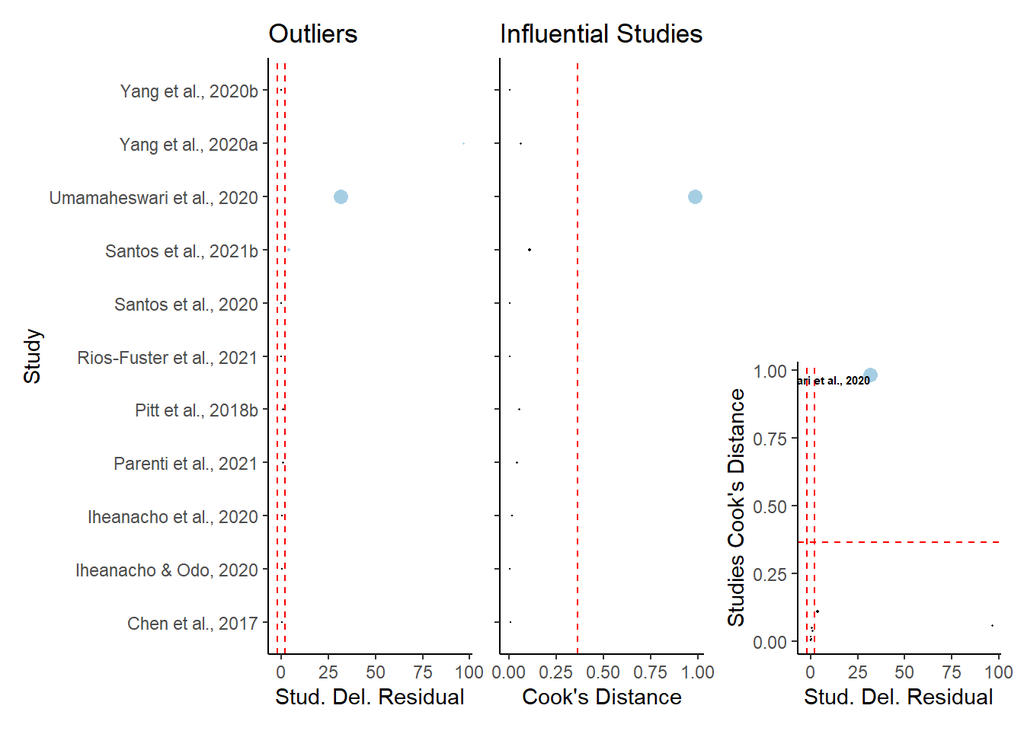

```r
influentialcases_plots(mRE, "ML_RobVar", "ML", 3)
```

# Multilevel meta-regression

SYRCLE PROTOCOL: Meta-regression will be used for outcomes with at least 10 experiments.

> The minimal number of studies or effect sizes required by a multilevel meta-regression remains unknown, albeit some simulation studies suggest that the estimates of model coefficients of a multilevel meta-regression are generally stable under various simulated situations.(Yang et al. 2023) … the complexity of parameterization of such a meta-regression requires a large dataset to make optimization algorithms free of convergence issues.(Yang et al. 2023)

## Model 1: Size, Duration, Development

```r
df_MR <- select(df, c("Year", "StudyID", "Study", "EScluster", "ESid", "DevelopmentalStage",
    "ExposureDurationDays", "ParticleSizeMean", "yi", "vi"))

mname1 <- "Base"
mname2 <- paste0(mname1, "_RobVar")

mods_formula <- formula(~ParticleSizeMean + ExposureDurationDays * DevelopmentalStage)

mMR[[mname1]] <- rma.mv(yi, VCV, random = RE_formula, mods = mods_formula, data = df_MR,
    slab = Study, method = "REML", test = "t", dfs = "contain", level = 95)  #it will only keep complete cases

nSt_MR <- mMR[[mname1]]$s.nlevels[1]  # number of studies
nEC_MR <- mMR[[mname1]]$s.nlevels[2]  # number of ESclusters
nES_MR <- mMR[[mname1]]$s.nlevels[3]  # number of independent ES

print(paste0("Number of studies: ", nSt_MR, ", number of ES clusters: ", nEC_MR,
    " and number of independent observations of ES: ", nES_MR))
```

```
[1] "Number of studies: 11, number of ES clusters: 21 and number of independent observations of ES: 45"
```

```r
mMR[[mname2]] <- robust(mMR[[mname1]], cluster = df_MR$Study, clubSandwich = TRUE,
    verbose = TRUE)
mMR[[mname2]] <- additional_results(mMR[[mname2]])
```

The meta-regression comprised 45 comparisons from 21 control group clusters of 11 independent studies.

#### Diagnostics plots

```
Multivariate Meta-Analysis Model (k = 45; method: REML)

  logLik  Deviance       AIC       BIC      AICc
-85.8943  171.7886  191.7886  208.1645  199.9367

Variance Components:

            estim    sqrt  nlvls  fixed                factor
sigma^2.1  0.0000  0.0000     11     no                 Study
sigma^2.2  0.0000  0.0001     21     no       Study/EScluster
sigma^2.3  3.8422  1.9601     45     no  Study/EScluster/ESid

Test for Residual Heterogeneity:
QE(df = 38) = 252.1244, p-val < .0001

Number of estimates:   45
Number of clusters:    11
Estimates per cluster: 0-18 (mean: 0.76, median: 0)

Test of Moderators (coefficients 2:7):¹
F(df1 = 6, df2 = 0) = 0.0000, p-val = NA

Model Results:

                                                 estimate      se¹      tval¹
intrcpt                                            2.1370  0.7648     2.7942
ParticleSizeMean                                  -0.0057  0.0108    -0.5268
ExposureDurationDays                              -0.3269  0.0314   -10.4244
DevelopmentalStageLarva                           -2.0618  0.9554    -2.1581
DevelopmentalStageJuvenile                         1.7150  5.2412     0.3272
ExposureDurationDays:DevelopmentalStageLarva       0.3430  0.1552     2.2102
ExposureDurationDays:DevelopmentalStageJuvenile    0.2272  0.0978     2.3229
                                                   df¹    pval¹     ci.lb¹
intrcpt                                          1.02   0.2150    -7.1599
ParticleSizeMean                                 1.08   0.6863    -0.1221
ExposureDurationDays                             1.13   0.0462    -0.6313
DevelopmentalStageLarva                          1.85   0.1740    -6.5150
DevelopmentalStageJuvenile                       1.09   0.7953   -53.6156
ExposureDurationDays:DevelopmentalStageLarva     1.65   0.1839    -0.4798
ExposureDurationDays:DevelopmentalStageJuvenile  1.14   0.2331    -0.7021
                                                   ci.ub¹
intrcpt                                          11.4339
ParticleSizeMean                                  0.1107
ExposureDurationDays                             -0.0224   *
DevelopmentalStageLarva                           2.3913
DevelopmentalStageJuvenile                       57.0455
ExposureDurationDays:DevelopmentalStageLarva      1.1659
ExposureDurationDays:DevelopmentalStageJuvenile   1.1565

---
Signif. codes:  0 '***' 0.001 '**' 0.01 '*' 0.05 '.' 0.1 ' ' 1

1) results based on cluster-robust inference (var-cov estimator: CR2,
   approx t/F-tests and confidence intervals, df: Satterthwaite approx)
```

|  | ML | REML |
| --- | --- | --- |
| ll | -98.35831 | -85.8943 |
| dev | 133.90810 | 171.7886 |
| AIC | 216.71661 | 191.7886 |
| BIC | 234.78324 | 208.1645 |
| AICc | 223.18720 | 199.9367 |

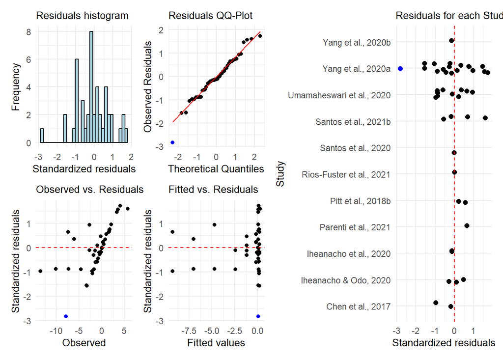

#### Influential cases

#### Orchard plots

(Nakagawa et al. 2021)

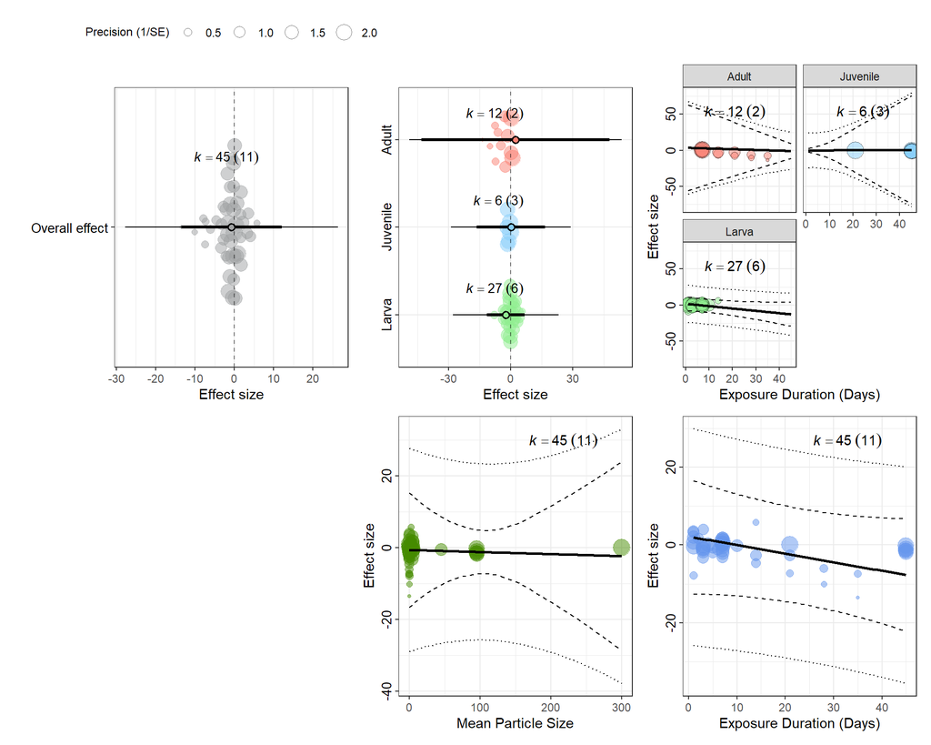

## Model 2: + Concentration

```
[1] "Number of studies: 7, number of ES clusters: 16 and number of independent observations of ES: 37"
```

The meta-regression comprised 37 comparisons from 16 control group clusters of 7 independent studies.

#### Diagnostics plots

```
Multivariate Meta-Analysis Model (k = 37; method: REML)

  logLik  Deviance       AIC       BIC      AICc
-71.3956  142.7912  160.7912  173.6971  169.3627

Variance Components:

            estim    sqrt  nlvls  fixed                factor
sigma^2.1  5.4106  2.3261      7     no                 Study
sigma^2.2  0.0000  0.0001     16     no       Study/EScluster
sigma^2.3  3.3611  1.8333     37     no  Study/EScluster/ESid

Test for Residual Heterogeneity:
QE(df = 31) = 209.9167, p-val < .0001

Number of estimates:   37
Number of clusters:    7
Estimates per cluster: 0-18 (mean: 0.63, median: 0)

Test of Moderators (coefficients 2:6):¹
F(df1 = 5, df2 = 0) = 0.0000, p-val = NA

Model Results:

                                              estimate      se¹     tval¹
intrcpt                                         1.4336  3.1975    0.4483
ParticleSizeMean                                0.0204  0.0172    1.1827
Concentration_mg_L                             -2.6299  1.4362   -1.8311
ExposureDurationDays                           -0.2928  0.0362   -8.0889
DevelopmentalStageLarva                         1.2100  3.4827    0.3474
ExposureDurationDays:DevelopmentalStageLarva    0.2702  0.1584    1.7057
                                                df¹    pval¹     ci.lb¹
intrcpt                                          1   0.7314   -38.7216
ParticleSizeMean                              1.07   0.4364    -0.1666
Concentration_mg_L                            1.65   0.2348   -10.2696
ExposureDurationDays                             1   0.0781    -0.7511
DevelopmentalStageLarva                       3.19   0.7499    -9.5066
ExposureDurationDays:DevelopmentalStageLarva  1.16   0.3107    -1.1851
                                                ci.ub¹
intrcpt                                       41.5887
ParticleSizeMean                               0.2074
Concentration_mg_L                             5.0099
ExposureDurationDays                           0.1655   .
DevelopmentalStageLarva                       11.9266
ExposureDurationDays:DevelopmentalStageLarva   1.7256

---
Signif. codes:  0 '***' 0.001 '**' 0.01 '*' 0.05 '.' 0.1 ' ' 1

1) results based on cluster-robust inference (var-cov estimator: CR2,
   approx t/F-tests and confidence intervals, df: Satterthwaite approx)
```

|  | ML | REML |
| --- | --- | --- |
| ll | -84.78008 | -71.39562 |
| dev | 109.21451 | 142.79124 |
| AIC | 187.56017 | 160.79124 |
| BIC | 202.05843 | 173.69713 |
| AICc | 194.22683 | 169.36267 |

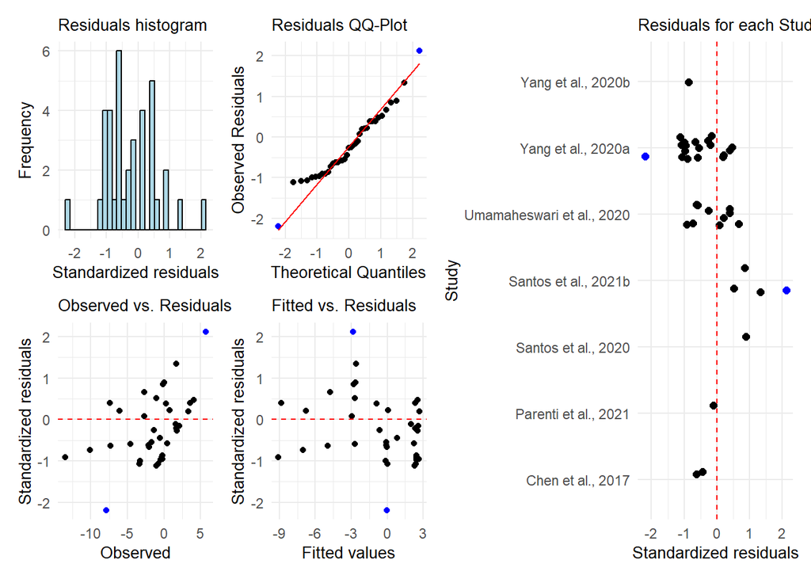

#### Influential cases

#### Orchard plots

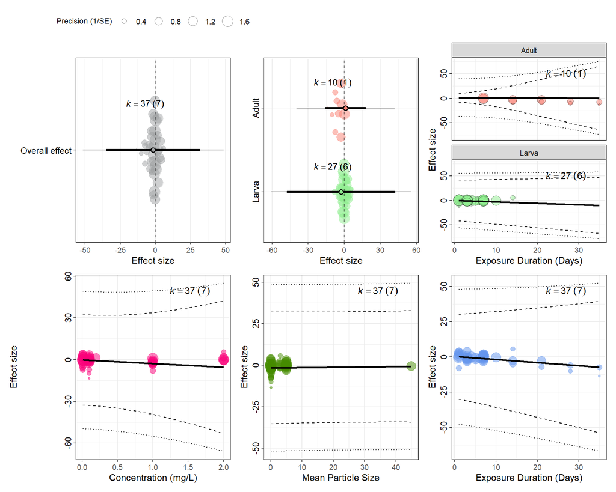

## Model 3: + ParticleMaterial

```
[1] "Number of studies: 11, number of ES clusters: 21 and number of independent observations of ES: 45"
```

The meta-regression comprised 45 comparisons from 21 control group clusters of 11 independent studies.

#### Diagnostics plots

```
Multivariate Meta-Analysis Model (k = 45; method: REML)

  logLik  Deviance       AIC       BIC      AICc
-82.3763  164.7525  188.7525  207.7548  202.3177

Variance Components:

            estim    sqrt  nlvls  fixed                factor
sigma^2.1  0.0000  0.0001     11     no                 Study
sigma^2.2  0.0000  0.0001     21     no       Study/EScluster
sigma^2.3  4.1627  2.0403     45     no  Study/EScluster/ESid

Test for Residual Heterogeneity:
QE(df = 36) = 251.9384, p-val < .0001

Number of estimates:   45
Number of clusters:    11
Estimates per cluster: 0-18 (mean: 0.76, median: 0)

Test of Moderators (coefficients 2:9):¹
F(df1 = 8, df2 = 0) = 0.0000, p-val = NA

Model Results:

                                              estimate      se¹      tval¹
intrcpt                                         2.7649  0.8898     3.1072
ParticleSizeMean                               -0.0036  0.0087    -0.4075
ExposureDurationDays                           -0.3283  0.0303   -10.8494
DevelopmentalStageLarva                        -2.1143  1.0363    -2.0402
DevelopmentalStageJuvenile                     10.9245  1.5898     6.8717
ParticleMaterialLDPE                           -5.6778  1.9257    -2.9485
ParticleMaterialPS                             -0.6244  0.4467    -1.3976
ParticleMaterialPVC                             0.3128  0.1777     1.7605
ExposureDurationDays:DevelopmentalStageLarva    0.3253  0.1516     2.1451
                                                df¹    pval¹     ci.lb¹
intrcpt                                       2.35   0.0729    -0.5610
ParticleSizeMean                               1.1   0.7488    -0.0934
ExposureDurationDays                          1.12   0.0448    -0.6259
DevelopmentalStageLarva                       1.83   0.1897    -6.9904
DevelopmentalStageJuvenile                    1.59   0.0362     2.0594
ParticleMaterialLDPE                          1.15   0.1819   -23.8903
ParticleMaterialPS                            1.64   0.3213    -3.0107
ParticleMaterialPVC                              1   0.3289    -1.9446
ExposureDurationDays:DevelopmentalStageLarva  1.81   0.1787    -0.3993
                                                ci.ub¹
intrcpt                                        6.0907   .
ParticleSizeMean                               0.0863
ExposureDurationDays                          -0.0308   *
DevelopmentalStageLarva                        2.7618
DevelopmentalStageJuvenile                    19.7895   *
ParticleMaterialLDPE                          12.5346
ParticleMaterialPS                             1.7620
ParticleMaterialPVC                            2.5702
ExposureDurationDays:DevelopmentalStageLarva   1.0499

---
Signif. codes:  0 '***' 0.001 '**' 0.01 '*' 0.05 '.' 0.1 ' ' 1

1) results based on cluster-robust inference (var-cov estimator: CR2,
   approx t/F-tests and confidence intervals, df: Satterthwaite approx)
```

|  | ML | REML |
| --- | --- | --- |
| ll | -98.47217 | -82.37626 |
| dev | 134.13582 | 164.75253 |
| AIC | 220.94434 | 188.75253 |
| BIC | 242.62429 | 207.75476 |
| AICc | 230.69434 | 202.31775 |

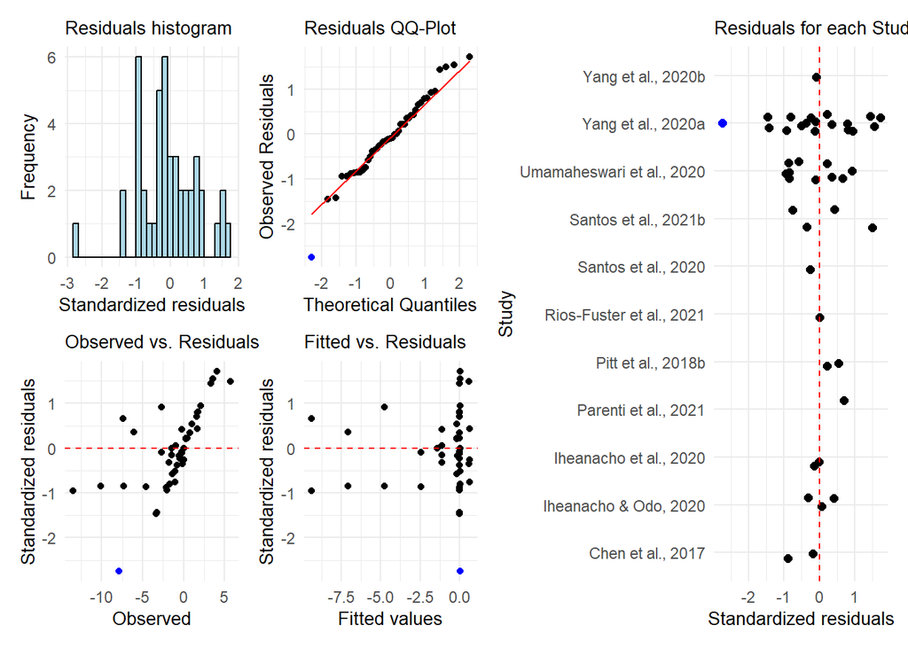

#### Influential cases

```
        Chen et al., 2017     Iheanacho & Odo, 2020    Iheanacho et al., 2020
              12.36009287                3.96296722                        NA
     Parenti et al., 2021        Pitt et al., 2018b  Rios-Fuster et al., 2021
               1.09806487                1.68621902                        NA
      Santos et al., 2020      Santos et al., 2021b Umamaheswari et al., 2020
               0.27654723                2.44353066                        NA
       Yang et al., 2020a        Yang et al., 2020b
              18.73060176                0.00621076
```

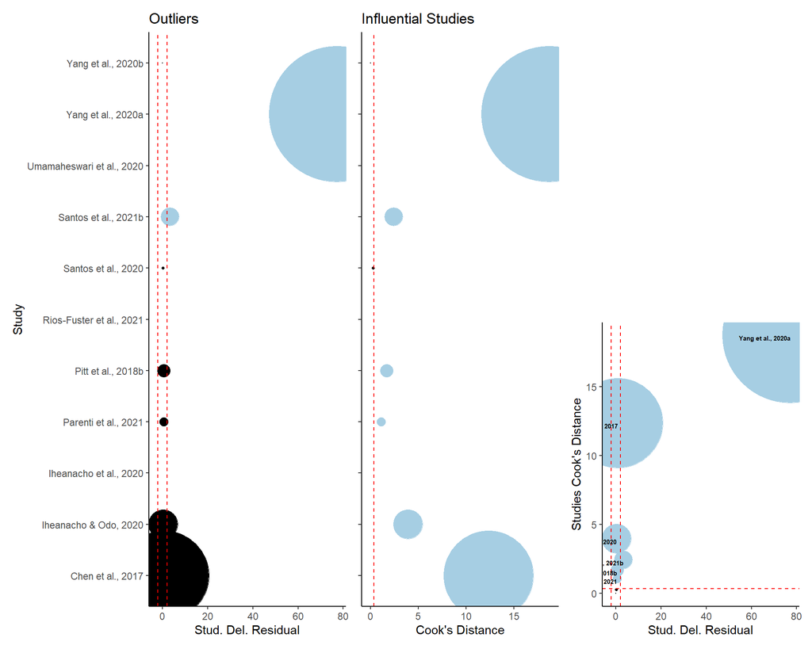

#### Orchard plots

# Referências

Harrer, Mathias, Pim Cuijpers, Toshi A. Furukawa, and David D. Ebert. n.d. *Chapter 9 Publication Bias | Doing Meta-Analysis in R*. https://bookdown.org/MathiasHarrer/Doing_Meta_Analysis_in_R/pub-bias.html.

Nakagawa, Shinichi, Malgorzata Lagisz, Michael D. Jennions, Julia Koricheva, Daniel W. A. Noble, Timothy H. Parker, Alfredo Sánchez-Tójar, Yefeng Yang, and Rose E. O’Dea. 2022. “Methods for Testing Publication Bias in Ecological and Evolutionary Meta-Analyses.” *Methods in Ecology and Evolution* 13 (1): 4–21. https://doi.org/10.1111/2041-210X.13724.

Nakagawa, Shinichi, Malgorzata Lagisz, Rose E. O’Dea, Joanna Rutkowska, Yefeng Yang, Daniel W. A. Noble, and Alistair M. Senior. 2021. “The Orchard Plot: Cultivating a Forest Plot for Use in Ecology, Evolution, and Beyond.” *Research Synthesis Methods* 12 (1): 4–12. https://doi.org/10.1002/jrsm.1424.

Stanley, T. D. 2017. “Limitations of PET-PEESE and Other Meta-Analysis Methods.” *Social Psychological and Personality Science* 8 (5): 581–91. https://doi.org/10.1177/1948550617693062.

Viechtbauer, Wolfgang. 2010. “Conducting Meta-Analyses in R with the Metafor Package.” *Journal of Statistical Software* 36 (August): 1–48. https://doi.org/10.18637/jss.v036.i03.

———. 2022. “Konstantopoulos (2011) [the Metafor Package].” https://www.metafor-project.org/doku.php/analyses:konstantopoulos2011.

Viechtbauer, Wolfgang, and Mike W.-L. Cheung. 2010. “Outlier and Influence Diagnostics for Meta-Analysis.” *Research Synthesis Methods* 1 (2): 112–25. https://doi.org/10.1002/jrsm.11.

Yang, Yefeng, Malcolm Macleod, Jinming Pan, Malgorzata Lagisz, and Shinichi Nakagawa. 2023. “Advanced Methods and Implementations for the Meta-Analyses of Animal Models: Current Practices and Future Recommendations.” *Neuroscience & Biobehavioral Reviews* 146 (March): 105016. https://doi.org/10.1016/j.neubiorev.2022.105016.